# R markdown Example

Jim Totland

17 12 2020

## R Markdown

This is an R Markdown document that was adapted from the default R Markdown script that opens automatically in R when you open a new Markdown file. Markdown is a simple formatting syntax for authoring HTML, PDF, and MS Word documents. For more details on using R Markdown see http://rmarkdown.rstudio.com.

```
## 'data.frame':    243 obs. of  8 variables:
##  $ bodyfat: num  12.3 6.1 25.3 10.4 28.7 20.9 19.2 12.4 4.1 11.7 ...
##  $ age    : int  23 22 22 26 24 24 26 25 25 23 ...
##  $ weight : num  70 78.7 69.9 83.9 83.7 ...
##  $ height : num  172 184 168 184 181 ...
##  $ bmi    : num  23.6 23.4 24.7 24.9 25.5 ...
##  $ neck   : num  36.2 38.5 34 37.4 34.4 39 36.4 37.8 38.1 42.1 ...
##  $ abdomen: num  85.2 83 87.9 86.4 100 94.4 90.7 88.5 82.5 88.6 ...
##  $ hip    : num  94.5 98.7 99.2 101.2 101.9 ...
```

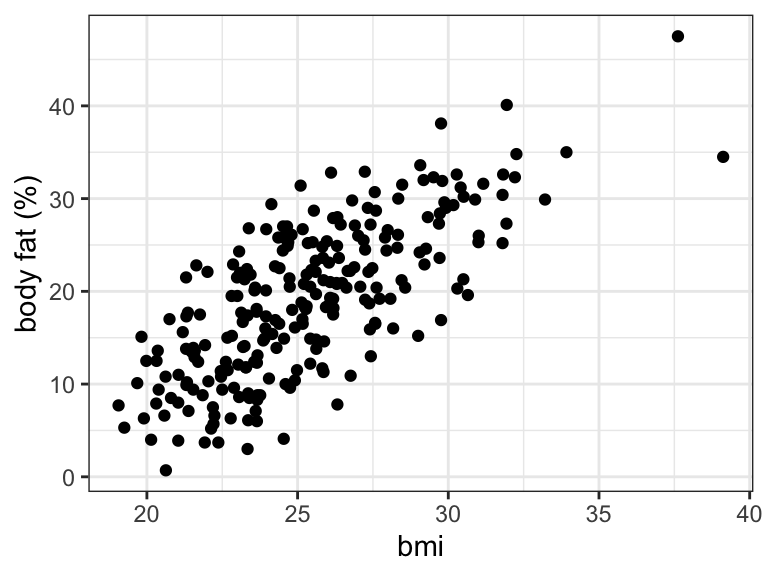

```r
library(ggplot2)
library(ggfortify)

d.bodyfat <- read.csv("~/Desktop/Jim/Github/rStuff/tutorial/data/bodyfat.csv")

str(d.bodyfat)
```

Note that in the header of this chunk we have modified some of the options to make the figure a bit nicer and centered in the output file. One tricky thing when you begin working with R Markdown is to find the right R chunk options. For an overview of the most important ones, we refer to the R Markdown cheatsheet, bottom of p.1 https://rmarkdown.rstudio.com/lesson-15.html.

## Combining R and LaTex

Students in mathematical sciences will most likely be familiar with [LaTex](https://www.latex-project.org/). A very useful feature of R Markdown is that it can easily be combined with LaTex to obtain nice mathematical typesetting, for example.

The Linear regression model of bodyfat ($y$) against bmi ($x$) can then be written as

$$y_i = \beta_0 + \beta_1 x_i + \epsilon_i, \quad \epsilon \sim \mathsf{N}(0,\sigma_E^2) \ .$$

## The linear regression example

Now we fit the above model. For illustration, we use `include=FALSE` in the options, but we will then print the results and the residual plots:

```r
summary(r.m1)
```

```
##
## Call:
## lm(formula = bodyfat ~ bmi, data = d.bodyfat)
##
## Residuals:
##      Min       1Q   Median       3Q      Max
## -13.5485  -3.5583   0.0785   4.0384  12.7330
##
## Coefficients:
##             Estimate Std. Error t value Pr(>|t|)
## (Intercept) -26.9844     2.7689  -9.746   <2e-16 ***
## bmi           1.8188     0.1083  16.788   <2e-16 ***
## ---
## Signif. codes:  0 '***' 0.001 '**' 0.01 '*' 0.05 '.' 0.1 ' ' 1
##
## Residual standard error: 5.573 on 241 degrees of freedom
## Multiple R-squared:  0.539,  Adjusted R-squared:  0.5371
## F-statistic: 281.8 on 1 and 241 DF,  p-value: < 2.2e-16
```

The residual plots look as follows:

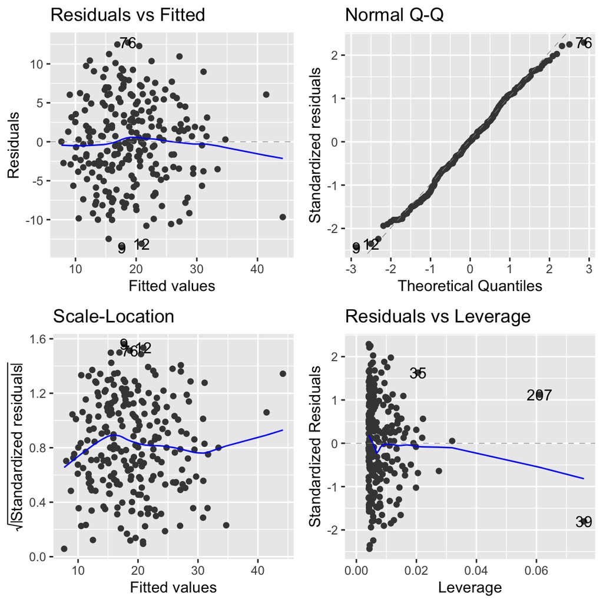

## Calling R outside of code chunks

One *very* useful feature of R Markdown is that we can write completely reproducible reports. If you detect an error in your data, for example, and you have to re-do the analysis, you have to copy-paste all the updated results if you use a word file, for example. In R Markdown, you can parameterize the results such that they are automatically updated.

The slope estimate in the regression of bodyfat against bmi is 1.82, for example. As you can see here (checking the Rmd), this is not hard-coded into the text, but directly uses the results from the R output, namely a rounded version of the `summary()` output.

## More plotting

Plottiing the pdf of the normal distribution with basic R:

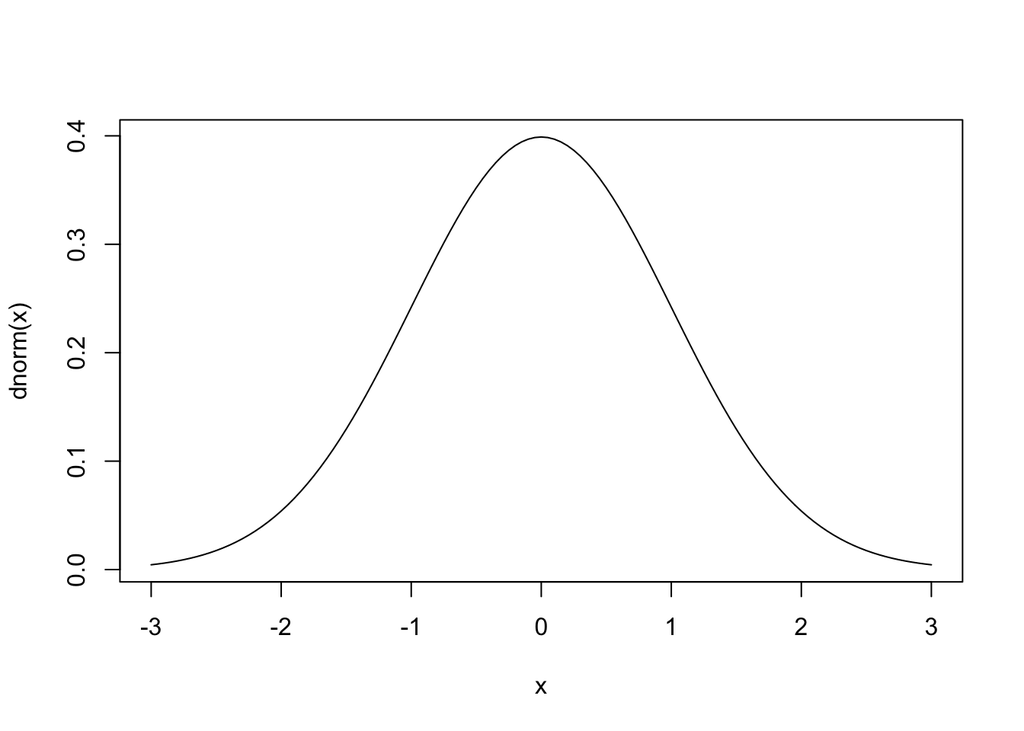

With `ggplot`:

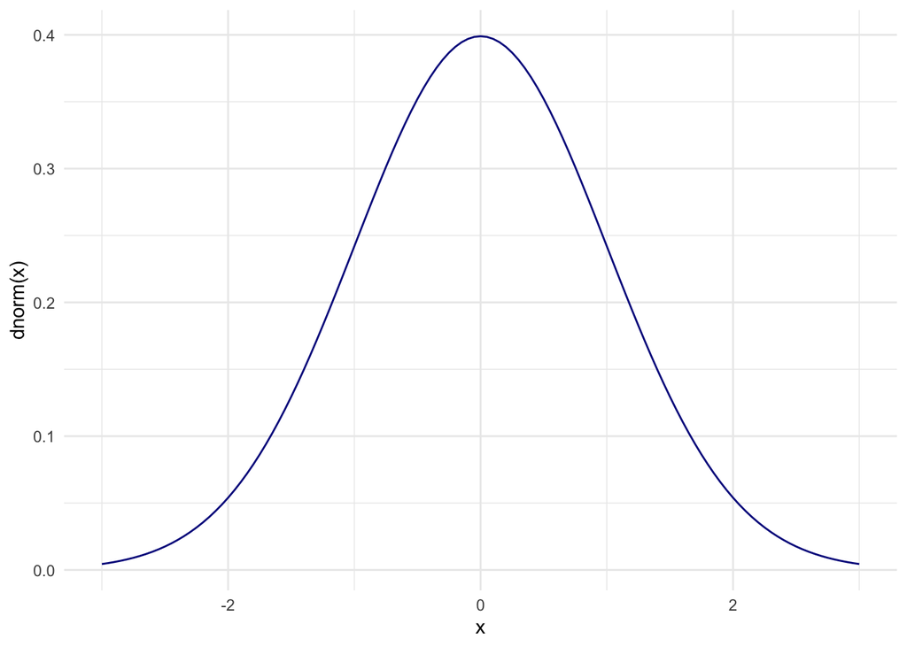

```r
dx  <- as.data.frame(x)
ggplot(dx, aes(x = x, y = dnorm(x))) +
  geom_line(color="darkblue") +
  theme_minimal()
```